# Prediction Assignment

Shawvin

8/15/2019

### Library loading and data downloading

```r
suppressPackageStartupMessages(library(DataExplorer))
suppressPackageStartupMessages(library(ggplot2))
suppressPackageStartupMessages(library(dplyr))
suppressPackageStartupMessages(library(tidyr))
suppressPackageStartupMessages(library(caret))

if(! file.exists("training.csv"))
download.file("https://d396qusza40orc.cloudfront.net/predmachlearn/pml-training.csv","training.csv")
if(! file.exists("testing.csv"))
download.file("https://d396qusza40orc.cloudfront.net/predmachlearn/pml-testing.csv","testing.csv")
```

### Data Loading

```r
training<-read.csv("training.csv")
testing<-read.csv("testing.csv")
dim(training)
```

```
[1] 19622   160
```

```r
t<-table(sapply(training,class))
t
```

```
 factor integer numeric
     37      35      88
```

The training set has19622 rows and 160 columns.Among these columns, there are 37 facotr varibles, 35 integer varible and 88 numeric varible.

### Exploratory Data Analysis

As we can see, there are more than 150 features for each observation, we would like to know which features are complete and suitable as candidate predictor.

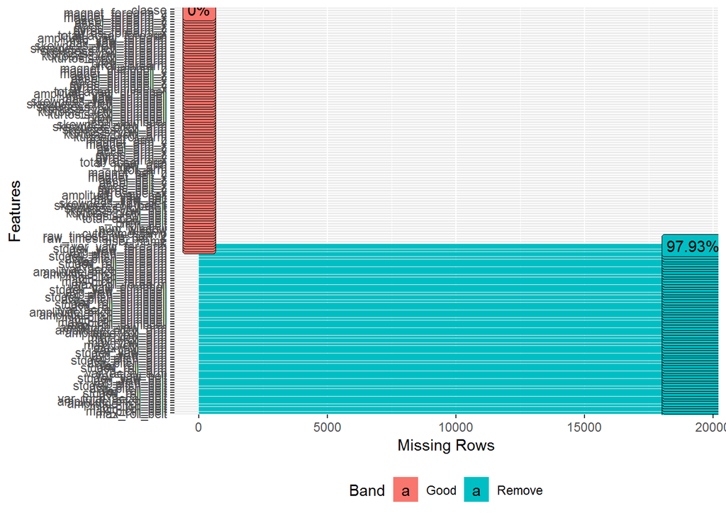

```r
plot_missing(training)
```

The are features have more than 90% missing values, which renders the feature unusable.We would like to kick out these features.

```r
## index1 checks the missing value in integer and numeric varibles
index1<-apply(training,2,function(x){sum(is.na(x))/length(x)>0.95})
training<-training[,!index1]
## index2 checks the missing value in factor varibles
index2<-apply(training,2,function(x){sum(x=="")/length(x)>0.95})
training<-training[,!index2]
```

After clearing those varibles that contain too much varible, we would like to clear other varibles deemed of no use in predicting. The first 7 features except names are experiment setting: sequence, timestamps…They are not useful in the predicting and should be excluded from the prediction.

```r
training<-training[,-c(1,3:7)]
dim(training)
```

```
[1] 19622    54
```

### Building models and selecting the model to predict

The models will have in sample and out of sample errors. In sample error occurs in the training set, and out of sample occurs when the model is applied in new data set. To reduce the out of sample, cross validation is used. Part of the training set is used as validation. In this analysis, k-fold cross validation is used. Four methods are selected to train the model. They tree, random forest, boosting tree and linear discriminant analysis.

```r
traincontrol<-trainControl(method="cv")
modFit1<-train(classe~.,data=training,method="rpart",trControl=traincontrol)
modFit2<-train(classe~.,data=training,method="rf",trControl=traincontrol)
modFit3<-train(classe~.,data=training,method="gbm",trControl=traincontrol,verbose=FALSE)
modFit4<-train(classe~.,data=training,method="lda",trControl=traincontrol)

modFit1
```

```
CART

19622 samples
   53 predictor
    5 classes: 'A', 'B', 'C', 'D', 'E'

No pre-processing
Resampling: Cross-Validated (10 fold)
Summary of sample sizes: 17659, 17658, 17661, 17660, 17659, 17661, ...
Resampling results across tuning parameters:

  cp          Accuracy   Kappa
  0.03567868  0.5043292  0.3525030
  0.05998671  0.4400237  0.2494793
  0.11515454  0.3322848  0.0729713

Accuracy was used to select the optimal model using the largest value.
The final value used for the model was cp = 0.03567868.
```

```r
modFit2
```

```
Random Forest

19622 samples
   53 predictor
    5 classes: 'A', 'B', 'C', 'D', 'E'

No pre-processing
Resampling: Cross-Validated (10 fold)
Summary of sample sizes: 17659, 17659, 17659, 17660, 17661, 17660, ...
Resampling results across tuning parameters:

  mtry  Accuracy   Kappa
   2    0.9948526  0.9934886
  29    0.9952603  0.9940044
  57    0.9902659  0.9876854

Accuracy was used to select the optimal model using the largest value.
The final value used for the model was mtry = 29.
```

```r
modFit3
```

```
Stochastic Gradient Boosting

19622 samples
   53 predictor
    5 classes: 'A', 'B', 'C', 'D', 'E'

No pre-processing
Resampling: Cross-Validated (10 fold)
Summary of sample sizes: 17659, 17661, 17661, 17659, 17659, 17658, ...
Resampling results across tuning parameters:

  interaction.depth  n.trees  Accuracy   Kappa
  1                   50      0.7524695  0.6862335
  1                  100      0.8216783  0.7742826
  1                  150      0.8546013  0.8160071
  2                   50      0.8560274  0.8175358
  2                  100      0.9087757  0.8845650
  2                  150      0.9323209  0.9143686
  3                   50      0.8955254  0.8677722
  3                  100      0.9435855  0.9286174
  3                  150      0.9633073  0.9535790

Tuning parameter 'shrinkage' was held constant at a value of 0.1

Tuning parameter 'n.minobsinnode' was held constant at a value of 10
Accuracy was used to select the optimal model using the largest value.
The final values used for the model were n.trees = 150,
 interaction.depth = 3, shrinkage = 0.1 and n.minobsinnode = 10.
```

```r
modFit4
```

```
Linear Discriminant Analysis

19622 samples
   53 predictor
    5 classes: 'A', 'B', 'C', 'D', 'E'

No pre-processing
Resampling: Cross-Validated (10 fold)
Summary of sample sizes: 17660, 17659, 17660, 17659, 17660, 17660, ...
Resampling results:

  Accuracy   Kappa
  0.7314246  0.6598765
```

```r
result<-predict(modFit2,testing)
```

As we can see, the random forest model has the highest accuracy. The model is used to predict the testing set.